# Exploratory Data Analysis - Exoplanets

2024-01-23

## Exoplanets - Do other earth like planets exist?

### Introduction

Exoplanets are defined as planets orbiting other stars. Astronomers long hypothesized these might exist, but only recently developed the technology to detect them consistently. The first exoplanet was discovered in 1992, with an additional 5500+ planets having been found since (Jan 2024). Telescopes such as Kepler and TESS were commissioned with the hope of one day answering the question - Do other habitable planets, or Earth analogs, exist?

**Project Goal**

The goal of this project is to to give a status update on our search for Earth analogs. Have we found any habitable planets yet? Why/why not, and do they even exist? We will be using data from the NASA Exoplanet Archive, a database containing information on every exoplanet discovered to date.

We will divide our analysis into the following sub-sections:  
- **Data Versions**: Deciding what cut of data we will use  
- **Data Cleaning**: Re-formating, mapping and handling potential data issues  
- **Validation**: Ensuring the data resembles reality by comparing it to known facts  
- **Analysis & Monitoring**: Can we answer our question? If not, is there a way to monitor progress towards our goal?

For information on the NASA Exoplanet Archive: https://exoplanetarchive.ipac.caltech.edu/docs/intro.html

**Other Notes**

Formatting - I was taught to use `=` to declare variables, not the customary R way of using `<-`.

#### Data Versions

We will be using the table `Planetary Systems Composite Parameters Planet Data` for our analysis. How to obtain yourself: Follow the link below > click on `Download Table` > select `CSV Format` + `Download All Columns` + `Download All Rows` > click `Download Table`

Link: https://exoplanetarchive.ipac.caltech.edu/cgi-bin/TblView/nph-tblView?app=ExoTbls&config=PSCompPars

```r
# Load Planetary Systems Composite Table
# Skip to line 316 as the lines prior only contain meta data.
# Might need to adjust if loading newer versions
raw_dt = fread('../data/PSCompPars_2024.01.23_14.28.52.csv', skip = 316)
dt = copy(raw_dt)
head(dt[, .(pl_name, hostname, gaia_id, hd_name)])
```

```
##       pl_name hostname                      gaia_id   hd_name
## 1:   11 Com b   11 Com Gaia DR2 3946945413106333696 HD 107383
## 2:   11 UMi b   11 UMi Gaia DR2 1696798367260229376 HD 136726
## 3:   14 And b   14 And Gaia DR2 1920113512486282240 HD 221345
## 4:   14 Her b   14 Her Gaia DR2 1385293808145621504 HD 145675
## 5: 16 Cyg B b 16 Cyg B Gaia DR2 2135550755683407232 HD 186427
## 6:   17 Sco b   17 Sco Gaia DR2 4342464209753404416
```

Note - Alternatively there is a bigger `Planet Systems Table` available as well. This “non-composite” table has multiple rows per exoplanet, one for each study a planet was cited in and for which measurements were taken. The composite table consolidates these data point into a single row per planet. NASA notes the composite table is not “necessarily self-consistent”, but provides a bigger picture.

Link: https://exoplanetarchive.ipac.caltech.edu/cgi-bin/TblView/nph-tblView?app=ExoTbls&config=PS

```r
# Load Non-composite table
non_composite_raw_dt = fread('../data/PS_2024.01.23_19.44.20.csv', skip = 292)
non_composite_raw_dt[, pl_pubdate := paste0(pl_pubdate, '-01')]
non_composite_raw_dt[, pl_pubdate := as.Date(pl_pubdate, format = '%Y-%m-%d')]
head(non_composite_raw_dt[, .(pl_name, hostname, gaia_id, hd_name, pl_pubdate)])
```

```
##     pl_name hostname                      gaia_id   hd_name pl_pubdate
## 1: 11 Com b   11 Com Gaia DR2 3946945413106333696 HD 107383 2011-08-01
## 2: 11 Com b   11 Com Gaia DR2 3946945413106333696 HD 107383 2008-01-01
## 3: 11 Com b   11 Com Gaia DR2 3946945413106333696 HD 107383 2023-08-01
## 4: 11 UMi b   11 UMi Gaia DR2 1696798367260229376 HD 136726 2017-03-01
## 5: 11 UMi b   11 UMi Gaia DR2 1696798367260229376 HD 136726 2011-08-01
## 6: 11 UMi b   11 UMi Gaia DR2 1696798367260229376 HD 136726 2009-10-01
```

Since the archive highlighted differences in the versions, lets spot check to ensure we are using the table best suited for us. Selecting several columns and compare the % of rows with NA values for each version should be a good start.

Note - We will go into detail on what the specific columns mean later. For now, the one column to remember is `pl_name` (Planet Name).

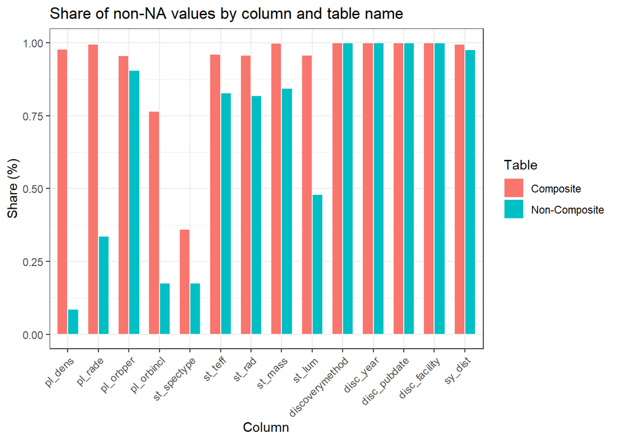

```r
# For non-composite table - Keep rows with data points from latest study only
# We could aggregate values column wise into one cell, but lets just see first
nc_index = non_composite_raw_dt[, .I[which.max(pl_pubdate)], by = pl_name]
nc_dt = non_composite_raw_dt[nc_index$V1]

# Combine both tables and compare # of NAs to get estimate on completeness
nc_dt = nc_dt[, .(pl_name, pl_dens, pl_rade, pl_orbper, pl_orbincl,
                  st_spectype, st_teff, st_rad, st_mass, st_lum,
                  discoverymethod, disc_year, disc_pubdate,
                  disc_facility, sy_dist, table_name = 'Non-Composite')]
c_dt = dt[, .(pl_name, pl_dens, pl_rade, pl_orbper, pl_orbincl, st_spectype,
              st_teff, st_rad, st_mass, st_lum, discoverymethod, disc_year,
              disc_pubdate, disc_facility, sy_dist, table_name = 'Composite')]
comb_dt = rbind(nc_dt, c_dt)

long_comb_dt = suppressWarnings(melt(comb_dt, id.vars = c('pl_name', 'table_name'),
                                     variable.name = 'column_name'))

# Calculate NA share per column
planet_count = long_comb_dt[, .(total_cnt = uniqueN(pl_name)), by = table_name]
long_agg_dt = long_comb_dt[!is.na(value) & !value == '']
long_agg_dt = long_agg_dt[, .(cnt = uniqueN(pl_name)), by = .(table_name, column_name)]
table_comp_dt = merge(long_agg_dt, planet_count, by = 'table_name')
table_comp_dt[, share := cnt / total_cnt]

ggplot(table_comp_dt, aes(fill = table_name, x = column_name, y = share)) +
  geom_bar(stat = "identity", position = 'dodge', width = 0.7, col=I("white")) +
  ylab("Share (%)") + xlab("Column") + labs(fill = "Table") +
  scale_x_discrete(guide = guide_axis(angle = 45)) +
  ggtitle('Share of non-NA values by column and table name') + theme_bw()
```

We immediately notice a very large discrepancy between the two tables. The composite table has a lot more data (ex. column `pl_dens`). Lets spot check the raw tables with planet `11 Com b` as example to see the difference.

```r
# Example `11 Com b`

# Non Composite Table
non_composite_raw_dt[pl_name == '11 Com b', .(pl_name, pl_dens, pl_rade, st_spectype, pl_pubdate)]
```

```
##     pl_name pl_dens pl_rade st_spectype pl_pubdate
## 1: 11 Com b      NA      NA             2011-08-01
## 2: 11 Com b      NA      NA      G8 III 2008-01-01
## 3: 11 Com b      NA      NA      G8 III 2023-08-01
```

vs.

```r
# Composite Table
dt[pl_name == '11 Com b', .(pl_name, pl_dens, pl_rade, st_spectype)]
```

```
##     pl_name pl_dens pl_rade st_spectype
## 1: 11 Com b    14.9    12.2      G8 III
```

The non-composite table has no values for the columns `pl_dens` (Planet Density) and `pl_rade` (Planet Radius), while the composite table does. The composite table must be filling in these value with some kind of calculation. Reading the documentation reveals that `Planet density` is in-fact calculated when not given.

Link: https://exoplanetarchive.ipac.caltech.edu/docs/pscp_calc.html

**Conclusion - Data Versions**

There are two versions of the data. The non-composite table has a row for each planet x study combination, while the composite table condenses these data points into one row per planet + tries to fill in values if possible. The fill makes the data a lot more comprehensive and we will therefore be using the composite table going forward.

#### Cleaning

There are 300+ columns in the table, but not all will be relevant to our analysis. To decide which to keep for our analysis, we need to develop some domain knowledge first.

To determine if a planet is habitable we will be looking at:  
- Planet Density  
- Planet Size  
- Star Type  
- Planet Orbit/Habitable Zone

**Planet Density**

References:

Densities for planets in solar system:

https://starchild.gsfc.nasa.gov/docs/StarChild/teachers/densities.html

Densities for icy objects:

https://en.wikipedia.org/wiki/Terrestrial_planet

Super Dense Gas Giants:

https://astronomy.stackexchange.com/questions/13382/planets-classification-by-density

```r
# Density Map
density_map = fread('../mappings/planet_density_map.csv')
max_density = max(dt[!is.na(pl_dens)]$pl_dens)
density_map[planet_type == 'Super Dense', upper_density := max_density]
setkey(density_map, lower_density, upper_density)
density_map
```

```
##    planet_type planet_density_unit lower_density upper_density
## 1:         Gas              g/cm^3             0             2
## 2:   Ice/Water              g/cm^3             2             3
## 3:        Rock              g/cm^3             3             8
## 4: Super Dense              g/cm^3             8           372
```

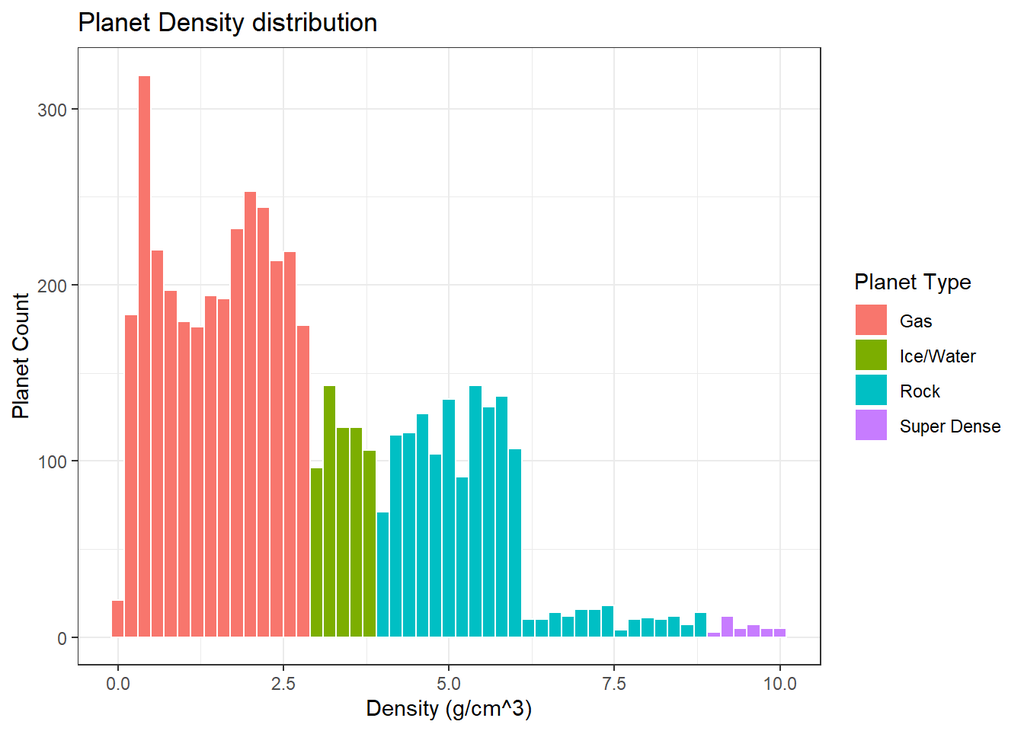

```r
# Join planet density map
dens_dt = dt[!is.na(pl_dens)]
dens_dt[, `:=` (lower_density = pl_dens, upper_density = pl_dens)]
dens_dt = foverlaps(dens_dt, density_map, type = 'within', mult = 'first')
dens_dt[, `:=` (i.lower_density = NULL, i.upper_density = NULL, planet_density_unit = NULL)]

# Plot planet density distribution
ggplot(dens_dt[pl_dens < 10], aes(pl_dens, fill = planet_type)) +
  geom_histogram(position = 'identity', binwidth = 0.2, col=I("white")) +
  ylab('Planet Count') + xlab('Density (g/cm^3)') + labs(fill = 'Planet Type') +
  ggtitle('Planet Density distribution') + theme_bw()
```

For the sake of this analysis, we will assume that only rocky planets are habitable and exclude Ice/Ocean planets.

**Planet Size**

There are two ways of measuring planet size to determine habitability. Its estimated an exoplanet needs to be between 0.5 - 1.6 Earth radii, or between 0.1 - 3 Earth masses. NASA Exoplanet Database provides us with data points on mass (column `pl_bmasse`) and radius (column `pl_rade`), both measured in Earth equivalents. We are going to be using mass as measurement for planet size going forward.

Link: https://phl.upr.edu/hwc

Link: https://exoplanetarchive.ipac.caltech.edu/docs/API_PS_columns.html

```r
# Planet size map
size_map = fread('../mappings/planet_size_map.csv')
max_mass = max(dens_dt[!is.na(pl_dens)]$pl_bmasse)
size_map[planet_size_type == 'Jovian (>50X Earth)', upper_mass := max_mass]
setkey(size_map, lower_mass, upper_mass)
size_map
```

```
##              planet_size_type planet_size_unit lower_mass upper_mass
## 1:      Sub-Earth(<0.1 Earth)     Earth Masses        0.0        0.1
## 2:                Earth Sized     Earth Masses        0.1        3.0
## 3: Mini-Neptune (3-10X Earth)     Earth Masses        3.0       10.0
## 4:   Neptunian (10-50X Earth)     Earth Masses       10.0       50.0
## 5:        Jovian (>50X Earth)     Earth Masses       50.0    89700.0
```

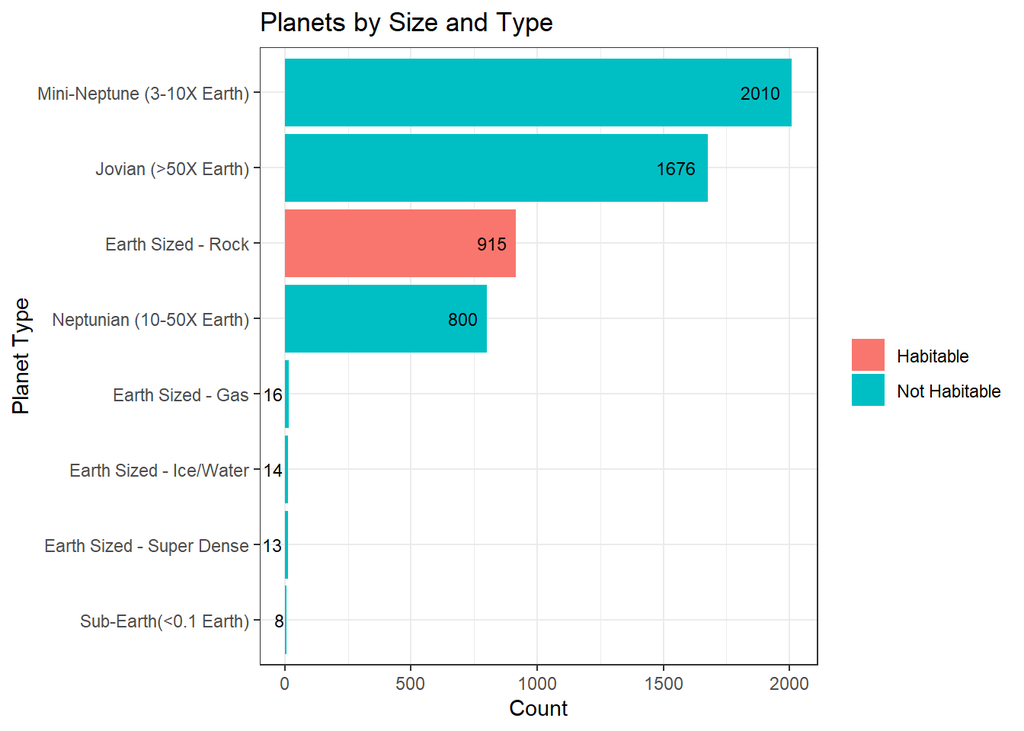

```r
# Join planet size map
size_dt = dens_dt[!is.na(pl_bmasse)]
size_dt[, `:=` (lower_mass = pl_bmasse, upper_mass = pl_bmasse)]
size_dt = foverlaps(size_dt, size_map, type = 'within', mult = 'first')
size_dt[, `:=` (i.lower_mass = NULL, i.upper_mass = NULL, planet_size_unit = NULL)]

# Plot planet size distribution
size_chart = size_dt[, .(pl_name, planet_type, planet_size_type)]
size_chart[, planet_type := ifelse(planet_size_type == 'Earth Sized',
                                   paste(planet_size_type, planet_type,
                                         sep = ' - '),
                                   planet_size_type)]
size_chart = size_chart[, .(cnt = .N), by = planet_type][order(-cnt)]

ggplot(size_chart, aes(x = reorder(planet_type, +cnt), cnt,
                       fill = factor(
                         ifelse(planet_type == 'Earth Sized - Rock',
                                'Habitable', 'Not Habitable')))) +
  geom_bar(stat = 'identity') + coord_flip() +
  geom_text(aes(label = cnt), hjust = 1.3, color = 'black', size = 3) +
  ylab('Count') + xlab('Planet Type') + labs(fill = '') +
  ggtitle('Planets by Size and Type') + theme_bw()
```

Just over 900, or 17% of exoplanets discovered pass our planet density and size requirements to consider them habitable. More factor determine habitability, such as atmospheric composition, magnetic fields, etc. but these are out of the scope of this project.

**Star Type**

We classify stars based on their surface temperature, which correlates to size. The main classifications are, largest to smallest, O, B, A, F, G (our sun), K, M (red dwarves). These are called spectral types, or spectral classifications.

Stars larger than the Sun (G-Type) radiate too intensely for life to exit. Smaller, K-type stars last longer and are more stable, making them even better candidates to host life. However, research is now showing they might emit too much X-ray radiation, potentially sterilizing planets orbiting them. M-type stars are the smallest on the list and emit the least light. A planet would have to orbit a lot closer to the star to be considered habitable. At those short distances planets tidally locks however. One side of the planet always faces the sun (similar to how the moon faces the earth), the other side always away. This might be too extreme an environment for life to exist on. We will therefore rule out K and M stars and focus on only G-Type.

Link: https://en.wikipedia.org/wiki/Stellar_classification#Class_M

```r
# Stellar Classification Map
st_map = fread('../mappings/spectral_class_map.csv')
max_temp = max(size_dt[!is.na(st_teff)]$st_teff)
st_map[spectral_class == 'O', upper_temp := max_temp]
setkey(st_map, lower_temp, upper_temp)
st_map
```

```
##    spectral_class lower_temp upper_temp
## 1:          Other          0       2400
## 2:              M       2400       3700
## 3:              K       3700       5200
## 4:              G       5200       6000
## 5:              F       6000       7500
## 6:              A       7500      10000
## 7:              B      10000      30000
## 8:              O      30000      57000
```

The Nasa Expolanet Archive only provides incomplete spectral classification, with ~3500 rows missing data. They do provide data on a stars surface temperature `st_teff`, with only ~200 missing entries. We will join our own spectral classification map to this column and compare vs the provided classification.

```r
# Provided classification distribution
size_dt[, provided_main_spectral_class := substr(st_spectype, 0, 1)]
stellar_type = size_dt[, .(pl_name, provided_main_spectral_class)]
stellar_type = stellar_type[, .N, by = provided_main_spectral_class]
stellar_type[order(provided_main_spectral_class)]
```

```
##     provided_main_spectral_class    N
##  1:                              3497
##  2:                            A   21
##  3:                            B   10
##  4:                            D    1
##  5:                            F  248
##  6:                            G  701
##  7:                            K  553
##  8:                            L    1
##  9:                            M  415
## 10:                            T    1
## 11:                            W    2
## 12:                            m    1
## 13:                            s    1
```

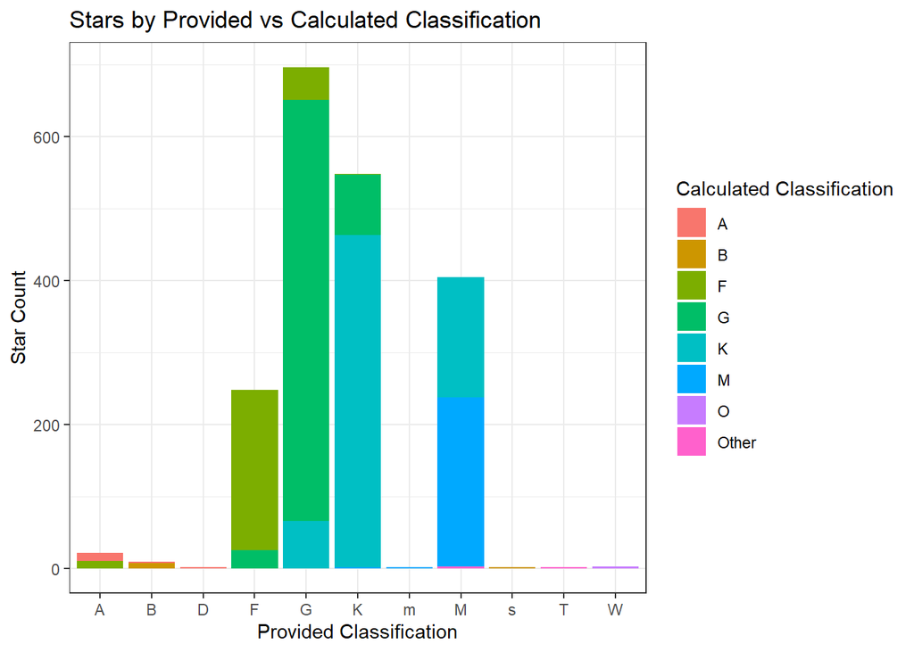

```r
# Join Spectral Classification map
st_dt = size_dt[!is.na(st_teff)]
st_dt[, `:=` (lower_temp = st_teff, upper_temp = st_teff)]
st_dt = foverlaps(st_dt, st_map, type = 'within', mult = 'first')
st_dt[, `:=` (i.lower_temp = NULL, i.upper_temp = NULL)]

# Plot Spectral Classification distribution
st_comp_dt = st_dt[, .(cnt = .N),
                   by = .(provided_main_spectral_class, spectral_class)]
ggplot(st_comp_dt[!provided_main_spectral_class == ''],
       aes(fill = spectral_class, y = cnt, x = provided_main_spectral_class)) +
  geom_bar(position="stack", stat="identity") +
  ylab('Star Count') + xlab('Provided Classification') +
  labs(fill = 'Calculated Classification') +
  ggtitle('Stars by Provided vs Calculated Classification') + theme_bw()
```

Provided and calculated star classifications mostly overlap. Where they are don’t, they are usually get placed into the adjacent category. Let’s spot check mismatches.

```r
# Examples of mismatches
st_dt[pl_name %in% c('11 Com b', '14 Her b'),
      .(pl_name, st_spectype, provided_main_spectral_class,
        spectral_class, st_teff, pl_bmassj, pl_radj, pl_orbper, disc_year)]
```

```
##     pl_name st_spectype provided_main_spectral_class spectral_class st_teff
## 1: 11 Com b      G8 III                            G              K    4874
## 2: 14 Her b        K0 V                            K              G    5338
##    pl_bmassj pl_radj pl_orbper disc_year
## 1:    15.464    1.09   323.210      2007
## 2:     8.053    1.12  1765.039      2002
```

Looking at literature we see that NASA agrees with our calculated classification for the stars above.

`11 Com b` Link: https://exoplanets.nasa.gov/exoplanet-catalog/6988/11-comae-berenices-b/

`14 Her b` Link: https://exoplanets.nasa.gov/exoplanet-catalog/6991/14-herculis-b/

**Orbit/Habitable Zone**

Earth is only habitable because it orbits the sun at a specific distance. Any closer and it would be too hot. Too far away and not enough sunlight would reach the planet to sustain life. To calculate the approximate habitable zone of a planet we use the following formula:

`r_inner = sqrt(star_luminosity/1.1); r_outer = sqrt(star_luminosity/0.53); units in AU (Astronomical Units)`

We can calculate `star_luminosity` using `st_lum` (stellar luminosity as a log10()). To convert the log, we just apply:

`star_lum_per_solar_lum = 10\^st_lum; units = "starluminocity"/"solar luminosity"`

Link: https://www.planetarybiology.com/calculating_habitable_zone.html

Link: https://exoplanetarchive.ipac.caltech.edu/docs/API_PS_columns.html

```r
# Habital zone calculation
st_dt[, st_lum_solar_eq := (10^st_lum)]
st_dt[, `:=` (hz_inner = sqrt(st_lum_solar_eq/1.1),
              hz_outer = sqrt(st_lum_solar_eq/0.53))]
head(st_dt[, .(pl_name, pl_orbper, pl_orbsmax, spectral_class, st_spectype,
               st_teff, st_lum, hz_inner, hz_outer, st_lum_solar_eq)], 6)
```

```
##       pl_name pl_orbper pl_orbsmax spectral_class st_spectype st_teff st_lum
## 1:   11 Com b   323.210      1.178              K      G8 III    4874  1.978
## 2:   11 UMi b   516.220      1.530              K      K4 III    4213  2.430
## 3:   14 And b   186.760      0.775              K      K0 III    4888  1.840
## 4:   14 Her b  1765.039      2.774              G        K0 V    5338 -0.153
## 5: 16 Cyg B b   798.500      1.660              G        G3 V    5750  0.097
## 6:   17 Sco b   578.380      1.450              K      K3 III    4157  2.254
##      hz_inner  hz_outer st_lum_solar_eq
## 1:  9.2961614 13.392513      95.0604794
## 2: 15.6424097 22.535234     269.1534804
## 3:  7.9305564 11.425154      69.1830971
## 4:  0.7994727  1.151760       0.7030723
## 5:  1.0661140  1.535897       1.2502590
## 6: 12.7733160 18.401875     179.4733627
```

At first glance, some of these habitable zone (`hz_inner`, `hz_outer`) and stellar luminosity values (`st_lum_solar_eq`), look wrong. `11 Com b` has an hz_inner radius of 9.29 AU, or 9X the Earth - Sun distance! However, spot checks confirm that they are correct.

Per Wikipedia, `11 Com B` orbits the star `11 Comae Berenices`, which is 110X as luminous as the sun. It might be a G type star, but its expanded to 16X the suns radius. This would explain why the inner and outer habitable zones are 9-13 AU out. Similar story with `11 UMi b`. Orbiting at 1.178 AU, 1.530 AU (see `pl_orbsmax`) away from the sun, these planets are getting cooked.

`11 Com b` link: https://en.wikipedia.org/wiki/11_Comae_Berenices

`11 UMi b` link: https://en.wikipedia.org/wiki/11_Ursae_Minoris

```r
# Filtering for Earth Sized planets that exist in our calculated habitable zone
st_dt[pl_orbsmax > hz_inner & pl_orbsmax < hz_outer &
        planet_size_type == 'Earth Sized',
      .(pl_name, spectral_class, planet_size_type, planet_type,
        pl_bmasse, pl_rade, pl_orbper, pl_orbsmax, hz_inner, hz_outer)]
```

```
##           pl_name spectral_class planet_size_type planet_type pl_bmasse pl_rade
##  1:     GJ 1002 b              M      Earth Sized        Rock     1.080   1.030
##  2:     GJ 1061 d              M      Earth Sized        Rock     1.640   1.160
##  3:      GJ 273 b              M      Earth Sized        Rock     2.890   1.510
##  4:    GJ 667 C f              M      Earth Sized        Rock     2.700   1.450
##  5:  Kepler-296 e              K      Earth Sized        Rock     2.960   1.530
##  6:  Kepler-442 b              K      Earth Sized        Rock     2.360   1.340
##  7: Proxima Cen b              M      Earth Sized        Rock     1.070   1.030
##  8:     TOI-700 d              M      Earth Sized        Rock     1.250   1.073
##  9:  TRAPPIST-1 e              M      Earth Sized        Rock     0.692   0.920
## 10:   Wolf 1069 b              M      Earth Sized        Rock     1.260   1.080
##      pl_orbper pl_orbsmax   hz_inner   hz_outer
##  1:  10.346500   0.045700 0.03575227 0.05150650
##  2:  13.031000   0.054000 0.03929196 0.05660595
##  3:  18.649800   0.091101 0.08939303 0.12878405
##  4:  39.026000   0.156000 0.11163584 0.16082815
##  5:  34.142110   0.169000 0.15660429 0.22561193
##  6: 112.305300   0.409000 0.32606460 0.46974489
##  7:  11.186800   0.048560 0.03813324 0.05493664
##  8:  37.423960   0.163300 0.14431240 0.20790363
##  9:   6.101013   0.029250 0.02242868 0.03231187
## 10:  15.564000   0.067200 0.05173729 0.07453531
```

None of the planets in our data fulfill all requirements to be considered habitable. For reasons previously determined, M and K-Type stars are most likely not suitable for life. Only G-type stars can host habitable planets, and we haven’t found a single match. Why is that?

Columns `pl_orbper` (days it takes for a planet to orbit a star) and `pl_orbsmax` (distance at which a planet orbits a star) gives us a hint. Most of these planets orbit their star closer and faster than Mercury orbits the sun (88 days, 0.4 AU).

Planets with small orbits seem to be over represented in our data. Can we confirm?

```r
# Solar system orbital map
solar_map = fread('../mappings/solar_system_orbit_map.csv')
setnames(solar_map, c('planet', 'orbit'), c('planet_orbit', 'upper_orbit'))
solar_map[, lower_orbit := shift(upper_orbit, 1)]
solar_map[is.na(lower_orbit), lower_orbit := 0]
max_orbit = st_dt[!is.na(pl_orbsmax), max(pl_orbsmax)]
solar_map[is.na(upper_orbit), upper_orbit := max_orbit]
solar_map[!planet_orbit == 'Beyond', planet_orbit := paste0('Sub-', planet_orbit)]
solar_map = solar_map[, .(planet_orbit, lower_orbit, upper_orbit)]
solar_map[, planet_orbit_rank := rank(lower_orbit)]
setkey(solar_map, lower_orbit, upper_orbit)
solar_map
```

```
##          planet_orbit lower_orbit upper_orbit planet_orbit_rank
##  1:       Sub-Mercury        0.00        0.40                 1
##  2:         Sub-Venus        0.40        0.72                 2
##  3:         Sub-Earth        0.72        1.00                 3
##  4:          Sub-Mars        1.00        1.50                 4
##  5: Sub-Asteroid Belt        1.50        2.80                 5
##  6:       Sub-Jupiter        2.80        5.20                 6
##  7:        Sub-Saturn        5.20        9.50                 7
##  8:        Sub-Uranus        9.50       19.00                 8
##  9:       Sub-Neptune       19.00       30.00                 9
## 10:         Sub-Pluto       30.00       39.00                10
## 11:            Beyond       39.00     7506.00                11
```

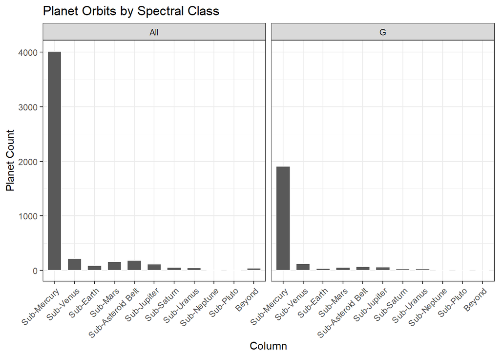

```r
# Join Solar Orbit map
so_dt = st_dt[!is.na(pl_orbsmax)]
so_dt[, `:=` (lower_orbit = pl_orbsmax, upper_orbit = pl_orbsmax)]
so_dt = foverlaps(so_dt, solar_map, type = 'within', mult = 'first')
so_dt[, `:=` (i.lower_orbit = NULL, i.upper_orbit = NULL)]

# Plot Planet Orbit distribution
so_comp_dt = rbind(so_dt[spectral_class == 'G', .(cnt = .N),
                         by = .(planet_orbit, planet_orbit_rank, spectral_class)],
                   so_dt[, .(cnt = .N, spectral_class = 'All'),
                         by = .(planet_orbit, planet_orbit_rank)])

ggplot(so_comp_dt, aes(x = reorder(planet_orbit, +planet_orbit_rank), y = cnt)) +
  geom_bar(stat = "identity", position = 'dodge', width = 0.7, col=I('white')) +
  facet_wrap(~spectral_class) +
  ylab('Planet Count') + xlab('Column') +
  scale_x_discrete(guide = guide_axis(angle = 45)) +
  ggtitle('Planet Orbits by Spectral Class') + theme_bw()
```

We can confirm that the vast majority of planets we are finding orbit closer to their star than that of Mercury. This holds true for G-Type stars as well as all. These are not the ideal orbits to to find habitable planets in!

To understand why, lets look at how we are detecting these exoplanets next

**Exoplanet Detection Methods**

```r
# Detection by method
so_dt[, .(cnt = .N, min_date = min(disc_year), max_date = max(disc_year), share = .N / dt[, .N]),
   by = discoverymethod][order(-cnt)]
```

```
##                   discoverymethod  cnt min_date max_date        share
##  1:                       Transit 3815     2002     2023 0.6850421979
##  2:               Radial Velocity 1022     1995     2023 0.1835158915
##  3:                       Imaging   62     2004     2023 0.0111330580
##  4:     Transit Timing Variations   22     2012     2023 0.0039504399
##  5:     Eclipse Timing Variations   11     2009     2019 0.0019752200
##  6:                  Microlensing    5     2012     2022 0.0008978273
##  7: Orbital Brightness Modulation    3     2011     2013 0.0005386964
##  8:                    Astrometry    2     2022     2023 0.0003591309
##  9:               Disk Kinematics    1     2019     2019 0.0001795655
## 10:                 Pulsar Timing    1     2011     2011 0.0001795655
## 11:   Pulsation Timing Variations    1     2007     2007 0.0001795655
```

Transit method refers to discovering a planet as it passes in between the star and us. The transiting planet will briefly dim the amount of light reaching us from the star. Think solar eclipse and how the moon temporarily blocks out sunlight. For this detection method to work a planet has to orbit right between the star and our telescope. Any slight offset from that and we might not be able to detect. Planets closer to the star will also be detected more frequently as they go around the star more frequently.

Link: https://exoplanets.nasa.gov/faq/31/whats-a-transit/

Radial velocity refers to discovering a planet by observing its star wobble. A planet orbiting a star will cause the star to slightly move off center. Think of the sport hammer throwing at the Olympics and how the athlete rotates off center. The bigger the planet compared to the star, the larger the wobble. This wobble causes a doppler shift in the light reaching us from the star, which is what we detect

Link: https://exoplanets.nasa.gov/resources/2285/radial-velocity/

We will classify all methods outside transit and radial velocity as “Other” going forward.

```r
# Map discovery methods
main_disc = c('Transit', 'Radial Velocity')
so_dt[, discoverymethod_cleaned := ifelse(discoverymethod %in% main_disc,
                                          discoverymethod, 'Other')]
so_dt[, disc_pubdate := as.Date(paste0(disc_pubdate, '-01'), format = '%Y-%m-%d')]
```

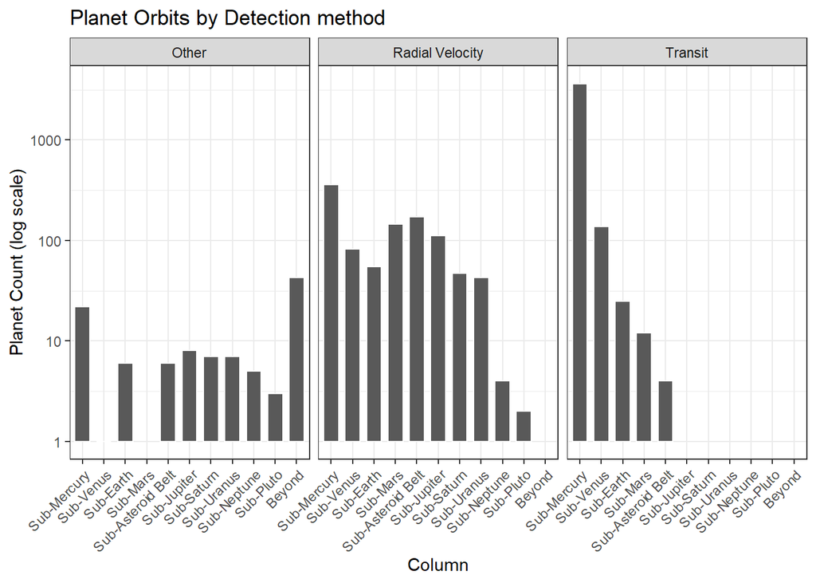

```r
# Plot Planet Orbit distribution
meth_comp_dt = so_dt[, .(cnt = .N), by = .(planet_orbit, planet_orbit_rank,
                                           discoverymethod_cleaned)]
ggplot(meth_comp_dt, aes(x = reorder(planet_orbit, +planet_orbit_rank), y = cnt)) +
  geom_bar(stat = "identity", position = 'dodge', width = 0.7, col=I('white')) +
  facet_wrap(~discoverymethod_cleaned) +
  ylab('Planet Count (log scale)') + xlab('Column') +
  scale_y_log10() +
  scale_x_discrete(guide = guide_axis(angle = 45)) +
  ggtitle('Planet Orbits by Detection method') + theme_bw()
```

In general, radial velocity is better at finding very large planets vs transit, as they are more likely to cause a sun to wobble (see below). So while its better at finding planets in a more habitable orbit, its worse at finding planets at the right size! Each detection method therefore has its strength and weaknesses.

One last thing to note about transit method. Its estimated that only 0.47% of planets orbiting their star at 1 AU (basically Earths orbit around the sun) can be detected via transit. A planets orbit needs to be perfectly aligned and cross the star right between it and our telescope for this method to work. In addition, we need a planet to transit the sun 3 times in order to classify it. The first detection establishes the presence of a potential candidate, the second establishes the time frame/period at which it orbits, and the third detection is to confirm that the orbital period is correct, and wasn’t two different objects passing the sun. This means that if you wanted to find an Earth analog around star similar to the sun, you would need to point your telescope at the same star for 3 years. To find a mars like planet with a 600+ day orbit you would need almost 6 years.

Link: https://en.wikipedia.org/wiki/Methods_of_detecting_exoplanets

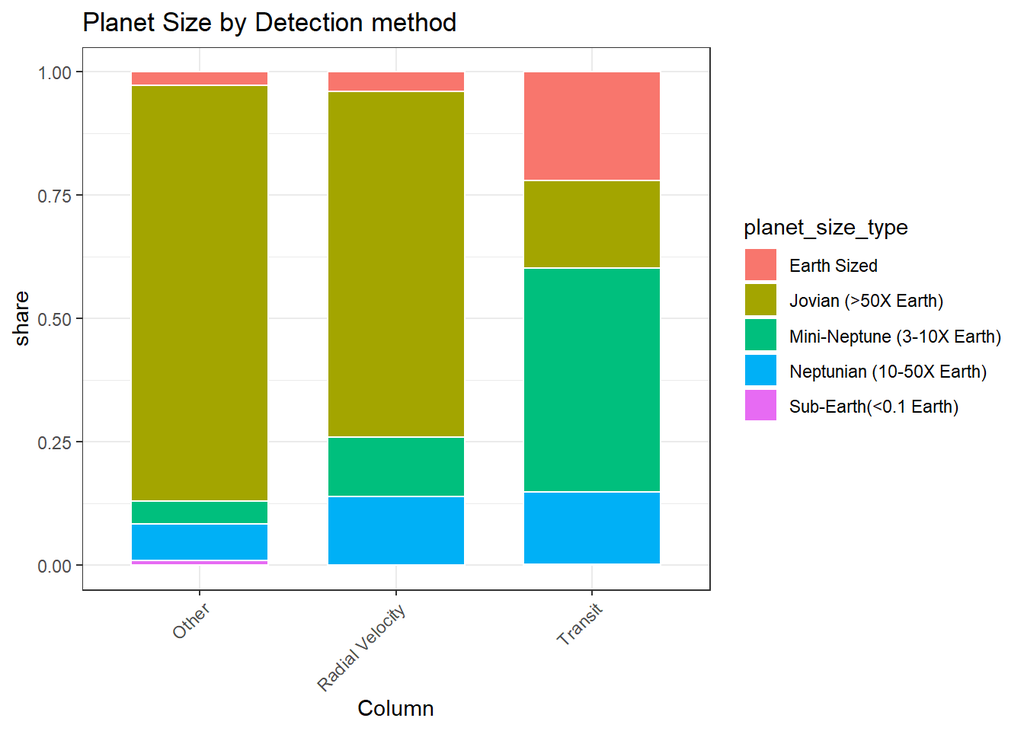

```r
# Plot Earth Sized planet distribution
es_dt = so_dt[, .(cnt = .N), by = .(planet_size_type, discoverymethod_cleaned)]
es_comp_total_dt = es_dt[, .(total_cnt = sum(cnt)), by = discoverymethod_cleaned]
es_comp_dt = merge(es_dt, es_comp_total_dt, by = 'discoverymethod_cleaned')
es_comp_dt[, share := cnt / total_cnt]
ggplot(es_comp_dt, aes(fill = planet_size_type, x = discoverymethod_cleaned, y = share)) +
  geom_bar(stat = 'identity', position = 'stack', width = 0.7, col=I('white')) +
  xlab('Column') +
  scale_x_discrete(guide = guide_axis(angle = 45)) +
  ggtitle('Planet Size by Detection method') + theme_bw()
```

**Discovery Facility**

We already mentioned the two big exoplanet finding missions, Kepler and TESS. Together they have found 60% of all exoplanets to date. We include “K2” in this as its essentially the Kepler telescope. In 2013 the pointing mechanism for the telescope broke, but engineers came up with a way to still make use of it. The types of observations they could make changed though.

```r
# Facilities ranked by exoplanets discovered
facility_rank = so_dt[, .(cnt = .N, min_date = min(disc_year),
                          max_date = max(disc_year), share = .N / dt[, .N]),
                      by = disc_facility][order(-cnt)]
facility_rank[, cumulative_share := cumsum(share)]
head(facility_rank[, -'max_date'])
```

```
##                                   disc_facility  cnt min_date      share
## 1:                                       Kepler 2702     2009 0.48518585
## 2: Transiting Exoplanet Survey Satellite (TESS)  355     2018 0.06374574
## 3:                                           K2  345     2014 0.06195008
## 4:                       Multiple Observatories  271     1996 0.04866224
## 5:                         La Silla Observatory  271     1999 0.04866224
## 6:                       W. M. Keck Observatory  168     1998 0.03016700
##    cumulative_share
## 1:        0.4851859
## 2:        0.5489316
## 3:        0.6108817
## 4:        0.6595439
## 5:        0.7082061
## 6:        0.7383731
```

```r
# Keep top 5 facilities and map rest to "Other"
so_dt[disc_facility == 'Transiting Exoplanet Survey Satellite (TESS)', disc_facility := 'TESS']
top5_facilities = so_dt[!disc_facility == 'Multiple Observatories'] # Remove as its not one entity
top5_facilities = head(top5_facilities[, .(cnt = .N), by = disc_facility][order(-cnt)], 5)$disc_facility
so_dt[, disc_facility_cleaned := ifelse(disc_facility %in% top5_facilities, disc_facility, 'Other')]
```

Lets repeat the orbit analysis, but this time look at the distribution by facility. Note - We can’t use a log scale on a stacked bar chart, so we will zoom in on the second chart

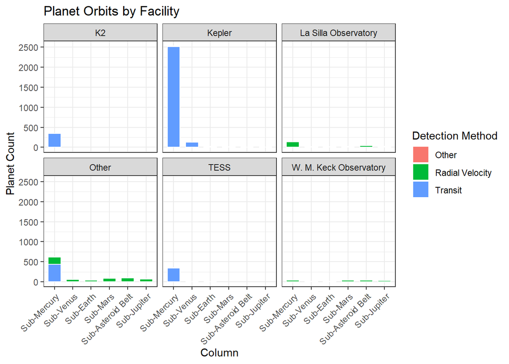

```r
# Plot Planet Orbit distribution by facility
fac_comp_dt = so_dt[planet_orbit_rank < 7, .(cnt = .N),
                    by = .(planet_orbit, planet_orbit_rank,
                           discoverymethod_cleaned, disc_facility_cleaned)]
ggplot(fac_comp_dt, aes(fill = discoverymethod_cleaned,
                        x = reorder(planet_orbit, +planet_orbit_rank), y = cnt)) +
  geom_bar(position = 'stack', stat = 'identity', width = 0.7, col=I('white')) +
  facet_wrap(~disc_facility_cleaned) +
  ylab('Planet Count') + xlab('Column') +
  labs(fill = 'Detection Method') +
  scale_x_discrete(guide = guide_axis(angle = 45)) +
  ggtitle('Planet Orbits by Facility') + theme_bw()
```

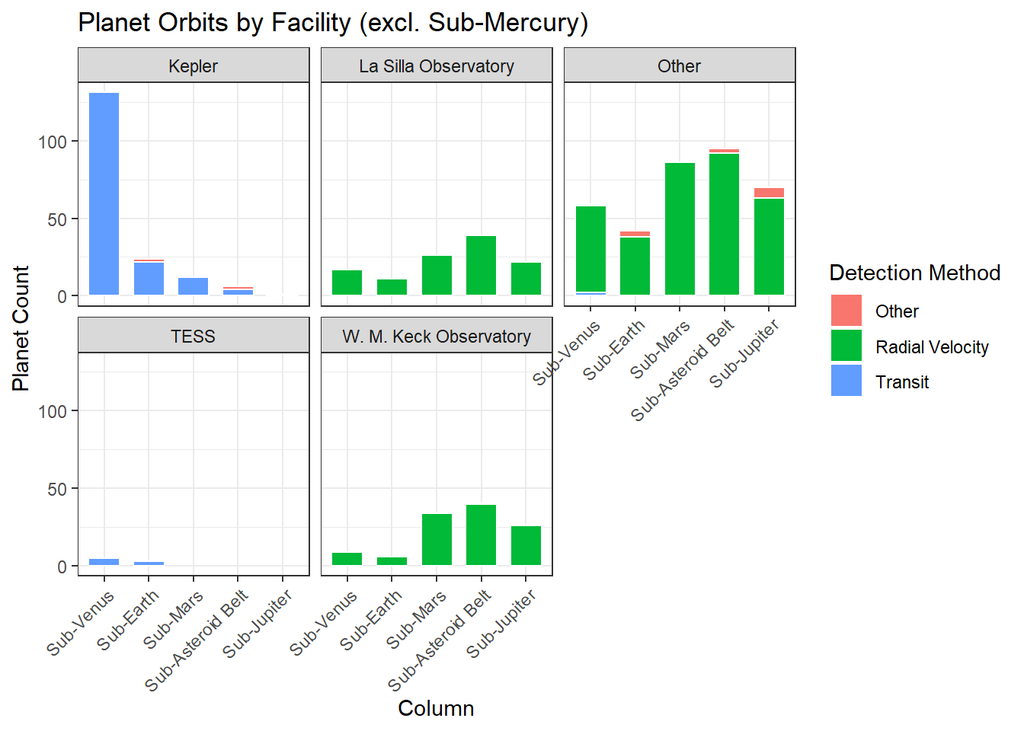

```r
# Exclude Sub-Mercury orbits
ggplot(fac_comp_dt[!planet_orbit == 'Sub-Mercury'], aes(fill = discoverymethod_cleaned,
                        x = reorder(planet_orbit, +planet_orbit_rank), y = cnt)) +
  geom_bar(position = 'stack', stat = 'identity', width = 0.7, col=I('white')) +
  facet_wrap(~disc_facility_cleaned) +
  ylab('Planet Count') + xlab('Column') +
  labs(fill = 'Detection Method') +
  scale_x_discrete(guide = guide_axis(angle = 45)) +
  ggtitle('Planet Orbits by Facility (excl. Sub-Mercury)') + theme_bw()
```

As we can see Kepler and Tess are excellent at finding a large quantity of planets. Most of these are in very close orbits to the sun - not ideal for habitability. They are finding some planets in habitable orbits (Sub-Earth, Sub-Mars), but all our other facilities are finding similar quantities, if not more. In a direct comparison, Kepler has been finding more planets closer to what we are looking for than TESS.

At this point there are few issues with the two space telescopes (TESS, Kepler), the other earth based telescopes.

Earth based telescopes have the issue that air movements in the atmosphere distort any observation. This is why most large earth based telescopes are on large mountains like in Hawaii or in the Andes. It is also why we launched telescopes like Tess and Kepler. There is no atmosphere in space reducing atmospheric interference. So in general, Earth based telescopes are better at looking at stars close by.

TESS scans 85% of the night sky, but only spends 27 days total observing a section. This means that if you wanted to discover a planet using the transit method, our most prolific detection method, you will have a hard time finding anything with a larger orbit, because whats the likely hood of a planet in an a 365 day orbit transiting in those 27 days - let alone confirming your findings, because you need it to orbit 3 times. A TESS detection needs to be followed up with a more long term observation from an earth telescope.

Kepler focused its telescope on on about 0.25% of the sky. It total observation time is a lot longer - making it great for planets with larger orbits. The issue is that it has such a narrow view that a larger amount of planets are at very far distances making follow up observations with earth based telescopes harder. See below

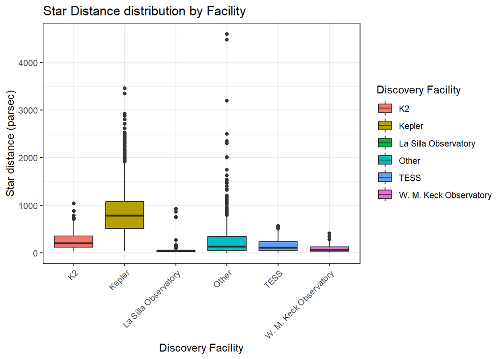

```r
# Star Distance distribution
distance_dt = so_dt[, .(cnt = .N), by = .(sy_dist, disc_facility_cleaned)]
ggplot(distance_dt[sy_dist < 5000], aes(x = disc_facility_cleaned, y = sy_dist, fill = disc_facility_cleaned)) +
  geom_boxplot() +
  ylab('Star distance (parsec)') + xlab('Discovery Facility') +
  labs(fill = 'Discovery Facility') +
  scale_x_discrete(guide = guide_axis(angle = 45)) +
  ggtitle('Star Distance distribution by Facility') + theme_bw()
```

**Conclusion - Data Cleaning**

We have taken considerable steps to map, clean and categories both planets and stars in our table. We have classified planets for habitability based on their density and mass, cleaned up the star type/stellar classification, calculated habitable zones for each star and relabeled detection methods and facilities.

While doing so, we already answered important questions about our search for an Earth analogs. We have not found a planet that meets all our requirements to be habitable. The reason for this lies mostly in our detection and search methods. Our main methods, Transit and Radial Velocity, both have strengths and weaknesses. Paired with how long our facilities/telescopes are spending each section of the sky searching for planets, we have not structured our search in a way thats optimal for discovering Earth analogs.

Before moving to the next step, lets select all the relevant columns we will need for our analysis:

```r
# Cleaned table
so_dt[, sy_dist := sy_dist * 3.26] # Convert star distance unit parasec to light years
clean_dt = so_dt[, .(pl_name, planet_type, planet_size_type, planet_orbit, pl_orbper, pl_orbsmax, pl_bmasse,
                     st_age, pl_rade, st_lum_solar_eq, spectral_class, st_teff, hz_inner, hz_outer, sy_dist,
                     disc_year, disc_pubdate, discoverymethod_cleaned, disc_facility_cleaned, disc_facility)]
```

#### Validation

At this point in our analysis we want to benchmark our cleaned table against known metrics. You generally want to make sure your data has some resemblance to reality, before building any full fledged analysis/dashboard. This is to 1) not produce unuseable output, 2) it gives you the chance to go back and iterate on your cleanup process should you notice things you missed, but can fix.

We will be comparing our data to:

1. Existing lists of potentially habitable exoplanets. How do our exoplanet categorizations stack up against what professional astronomers put together
2. The Herzsprung-Russell Diagram. This is a diagram used to show the distribution and classification of stars in our nearby milkyway. Can we reproduce this using our data, or do the type of stars with exoplanets look totally different

**Habitable exoplanet lists**

There are two lists we can compare our exoplanets too. 1) From the Planetary Hability Lab (PHL) at Arecibo in Puerto Rico (Arecibo was the telescope featured in James Bond - Golden Eye), 2) List of habitable planets on wikipedia.

For now, we will compare to PHL at Arecibo, because I can download their list and there is a lot of overlap between the two.

Link: https://phl.upr.edu/hwc

Link: https://en.wikipedia.org/wiki/List_of_potentially_habitable_exoplanets

```r
# Comparison to PHL at Arecibo
# We will be using their "Conservative Sample" of 29 planets
phl_dt = fread('../data/hwc_table_all.csv')
setnames(phl_dt, c('Mass<br>(M<sub>E</sub>)', 'Radius<br>(R<sub>E</sub>)'),
         c('mass', 'radius'))
head(phl_dt[(between(mass, 0.1, 3) | between(radius, 0.5, 1.6)),
            .(Name, Type, `Detection Method`, mass, radius)][order(Name)])
```

```
##          Name          Type Detection Method mass radius
## 1:  GJ 1002 b M Warm Terran  Radial Velocity 1.08   1.03
## 2:  GJ 1002 c M Warm Terran  Radial Velocity 1.36   1.10
## 3:  GJ 1061 c M Warm Terran  Radial Velocity 1.74   1.18
## 4:  GJ 1061 d M Warm Terran  Radial Velocity 1.64   1.16
## 5:   GJ 273 b M Warm Terran  Radial Velocity 2.89   1.51
## 6: GJ 667 C e M Warm Terran  Radial Velocity 2.70   1.45
```

PHL provides a conservative list of 29, and an optimistic list of 40 planets. Above, we use the conservative list (mass between 0.1 and 3 earths, OR radius 0.5 - 1.6). As we can see, they do not filter on spectral class and include M, K type stars.

If we compare their list to ours below, we see a lot of overlap. This is exactly what we want to see! The first five planets (GJ 1002 b to Kepler-1652 b) are all included in their list as well. So clearly we are doing something correctly.

```r
# Our list of habitable exoplanets
# We include Mini-Neptunes and dont filter on spectral_class
head(clean_dt[planet_type == 'Rock' & between(pl_orbsmax, hz_inner, hz_outer)
              & planet_size_type %in% c('Earth Sized', 'Mini-Neptune (3-10X Earth)'),
              .(pl_name, planet_size_type, pl_orbsmax, pl_bmasse, pl_rade)])
```

```
##          pl_name           planet_size_type pl_orbsmax pl_bmasse pl_rade
## 1:     GJ 1002 b                Earth Sized   0.045700      1.08    1.03
## 2:     GJ 1061 d                Earth Sized   0.054000      1.64    1.16
## 3:      GJ 273 b                Earth Sized   0.091101      2.89    1.51
## 4:    GJ 667 C f                Earth Sized   0.156000      2.70    1.45
## 5: Kepler-1652 b Mini-Neptune (3-10X Earth)   0.165400      3.19    1.60
## 6:   Kepler-22 b Mini-Neptune (3-10X Earth)   0.812000      9.10    2.10
```

Lets look at differences

```r
# Difference in exoplanet lists
phl_exoplanets = phl_dt[(between(mass, 0.1, 3) | between(radius, 0.5, 1.6))]
phl_exoplanets = phl_exoplanets[, .(pl_name = Name, table = 'PHL Arecibo')]

our_exoplanets = clean_dt[planet_type == 'Rock' & between(pl_orbsmax, hz_inner, hz_outer)
                          & planet_size_type %in% c('Earth Sized', 'Mini-Neptune (3-10X Earth)')]
our_exoplanets = our_exoplanets[, .(pl_name, table = 'Our list')]

exo_comp_dt = rbind(phl_exoplanets, our_exoplanets)
exo_comp_dt = exo_comp_dt[, .(cnt = .N, table = max(table)), by = pl_name]
exo_comp_dt[cnt == 2, table := 'Both']

exo_comp_dt[, .(cnt = .N), by = table]
```

```
##          table cnt
## 1:        Both  12
## 2: PHL Arecibo  17
## 3:    Our list   1
```

12/13 of the planets we classified as exoplanets are in their list. I think that speaks to our cleaning! BTW - our name mapping is identical, meaning they are using the same underlying data. Lets check next why they classified an additional 17 planets as habitable. What did we miss/not consider?

```r
missing_exo_dt = clean_dt[pl_name %in% exo_comp_dt[table == 'PHL Arecibo', unique(pl_name)]]
missing_exo_dt[, .(pl_name, planet_orbit, pl_orbsmax, hz_inner, hz_outer)]
```

```
##                pl_name planet_orbit pl_orbsmax   hz_inner   hz_outer
##  1:          GJ 1002 c  Sub-Mercury    0.07380 0.03575227 0.05150650
##  2:          GJ 1061 c  Sub-Mercury    0.03500 0.03929196 0.05660595
##  3:         GJ 667 C e  Sub-Mercury    0.21300 0.11163584 0.16082815
##  4:             K2-3 d  Sub-Mercury    0.20140 0.23110198 0.33293700
##  5:            K2-72 e  Sub-Mercury    0.10600 0.11502802 0.16571509
##  6:      Kepler-1229 b  Sub-Mercury    0.30060 0.16323138 0.23515925
##  7:      Kepler-1649 c  Sub-Mercury    0.06490 0.06851784 0.09871021
##  8:       Kepler-186 f    Sub-Venus    0.43200 0.22351345 0.32200459
##  9:         Ross 128 b  Sub-Mercury    0.04960 0.05738570 0.08267269
## 10:          TOI-700 e  Sub-Mercury    0.13400 0.14431240 0.20790363
## 11:       TRAPPIST-1 d  Sub-Mercury    0.02227 0.02242868 0.03231187
## 12:       TRAPPIST-1 f  Sub-Mercury    0.03849 0.02242868 0.03231187
## 13:       TRAPPIST-1 g  Sub-Mercury    0.04683 0.02242868 0.03231187
## 14: Teegarden's Star b  Sub-Mercury    0.02520 0.02575157 0.03709899
## 15: Teegarden's Star c  Sub-Mercury    0.04430 0.02575157 0.03709899
```

Looks like 15/17 planet names match those in our table.

We see one Super Dense planet `K2-3 d`, otherwise all are Earth sized and rocky. Checking `K2-3 d` on Wikipedia reveals, that our density measurement might be out of date. It looks like the density was recently reduced (see link below).

Link: https://en.wikipedia.org/wiki/K2-3d

**Herzsprung-Russell Diagram**

Again, its a diagram used to show the distribution and classification of stars. Ours looks very similar to the center of the one on Wikipedia. We are missing some white dwarves and super giants, but this tells me that 1) our star data is reasonable 2) we are finding exoplanets distributed across all the mid-sized main star types.

Link: https://en.wikipedia.org/wiki/Hertzsprung%E2%80%93Russell_diagram

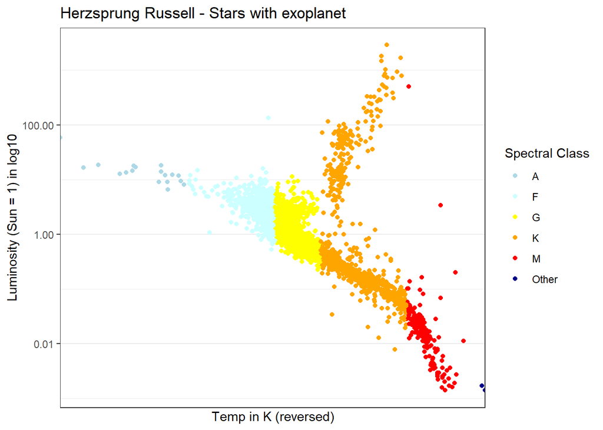

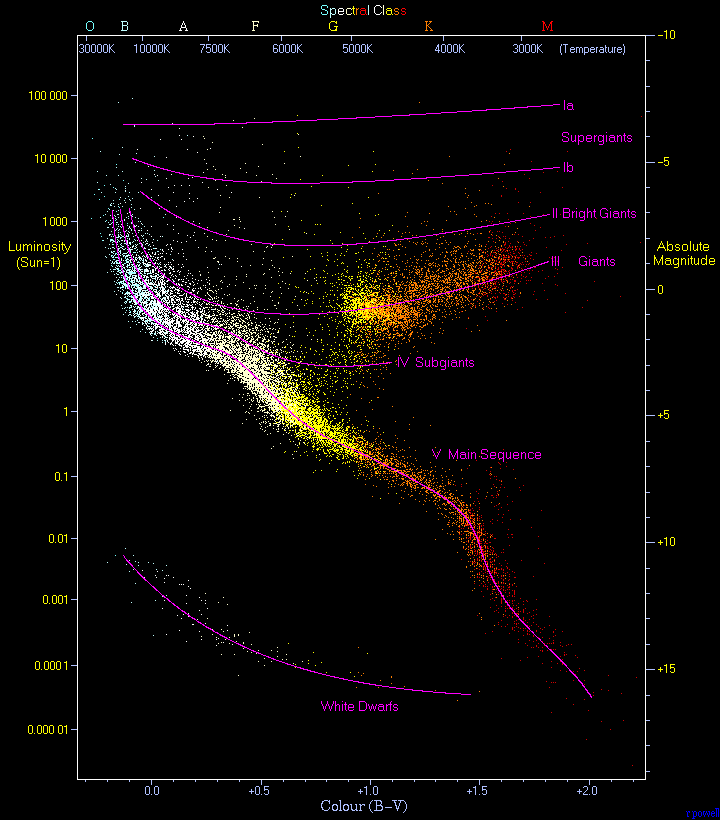

Wikipedia Herzsprung-Russell

```r
# Herzsprung Russell of stars with exoplanets
herz_dt = clean_dt[, .(st_lum_solar_eq, st_teff, pl_name, spectral_class)]
herz_colors = c('lightblue', '#ccffff', 'yellow', 'orange', 'red', 'darkblue')
ggplot(herz_dt[st_teff < 10000 & st_lum_solar_eq >= 0.001], aes(x = -st_teff, y = st_lum_solar_eq,
                                     color = spectral_class)) +
  scale_color_manual("Spectral Class", values = herz_colors) +
  scale_y_log10(labels = scales::comma) +
  geom_point() +
  ylab('Luminosity (Sun = 1) in log10') + xlab('Temp in K (reversed)') +
  scale_x_discrete(guide = guide_axis(angle = 45)) +
  ggtitle('Herzsprung Russell - Stars with exoplanet') + theme_bw()
```

**Conclusion - Validation**

We have shown that our cleaning methods resulted in an exoplanet list with a large amount of overlap to the lists created by professional Astronomers. In addition, our star distribution looks very similar to that of a Herzsprung-Russell diagram.

We can be confident that the data we are using has some scientific basis in reality.

#### Analysis & Monitoring

We previously established that none of our discovered exoplanets meet the full list of requirements to be considered habitable, or Earth analogs. Our current discovery methods simply aren’t being used in a way to optimize Earth analogs.

What we are going to do next is create a chart that allows us to track progress towards finding habitable exoplanets over time. We have no problem finding G-Type stars, Earth sized planets, etc. - any other feature making Earth habitable - except that the orbits we are finding them in are too small.

As a last step of this analysis lets set up a chart to monitor if this should change down the road. We are going to track any discovery facility currently active (excluding Kepler/K2), that has a consistent rate of detection and break those out by showing their average planetary orbits over time. This will give us an idea if we should expect any detection in the near future.

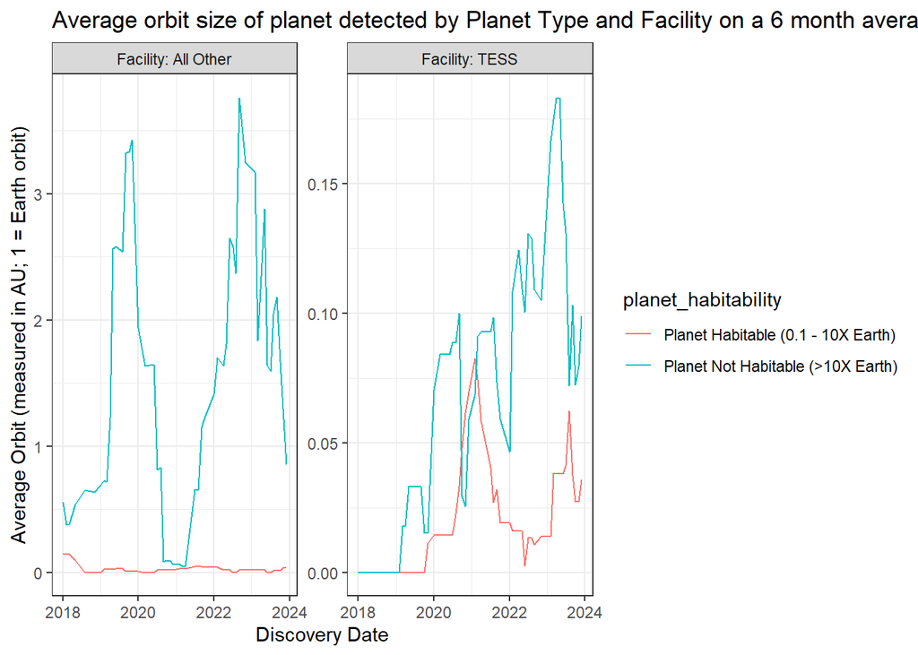

```r
# Filtering for habitability & Aggregating table for charting
db_dt = clean_dt[!disc_facility %in% c('K2', 'Kepler') &
                   spectral_class == 'G' &
                   !planet_size_type == 'Sub-Earth(<0.1 Earth)']
db_dt[, planet_habitability :=
        ifelse(planet_size_type %in% c('Earth Sized', 'Mini-Neptune (3-10X Earth)'),
               'Planet Habitable (0.1 - 10X Earth)', 'Planet Not Habitable (>10X Earth)')]
max_date = db_dt[!is.na(disc_pubdate), max(disc_pubdate)]
cutoff_date = max_date %m-% months(12)
breakout_facilities = db_dt[disc_pubdate >= cutoff_date,
                            .(month_cnt = uniqueN(disc_pubdate)), by = disc_facility]
breakout_fac_list = breakout_facilities[!disc_facility == 'Multiple Observatories']
breakout_fac_list = breakout_fac_list[month_cnt >= 8]$disc_facility
db_dt[, target_facility := ifelse(disc_facility %in% breakout_fac_list,
                                  disc_facility, 'All Other')]
agg_db_dt = db_dt[, .(cnt = .N, avg_orbit = mean(pl_orbsmax, na.rm = T)),
                  by = .(target_facility, disc_pubdate, planet_habitability)]

# Filling in publication date gaps
disc_pubdate = agg_db_dt[, unique(disc_pubdate)]
target_facility = agg_db_dt[, unique(target_facility)]
planet_habitability = agg_db_dt[, unique(planet_habitability)]
all_comb = CJ(disc_pubdate, target_facility, planet_habitability)
output_dt = merge(all_comb, agg_db_dt,
                  by = c('disc_pubdate', 'target_facility', 'planet_habitability'), all = T)
output_dt[is.na(avg_orbit), avg_orbit := 0]

setorder(output_dt, target_facility, planet_habitability, disc_pubdate)
output_dt[, avg_orbit_t6m := frollmean(avg_orbit, 6), by = .(target_facility, planet_habitability)]
chart_dt = suppressWarnings(melt(output_dt, id.vars = c('target_facility',
                                                        'planet_habitability', 'disc_pubdate')))
chart_dt[is.na(value), value := 0]
chart_dt[, target_facility := paste0('Facility: ', target_facility)]

# Chart
ggplot(chart_dt[disc_pubdate > '2017-12-31' & variable == 'avg_orbit_t6m'],
       aes(disc_pubdate, value, color = planet_habitability, group = planet_habitability)) +
  geom_line() +
  facet_wrap(~target_facility, scales = 'free') +
  ylab('Average Orbit (measured in AU; 1 = Earth orbit)') + xlab('Discovery Date') +
  labs(fill = 'Planet Type') +
  ggtitle('Average orbit size of planet detected by Planet Type and Facility on a 6 month average') + theme_bw()
```

**Conclusion**